# Project Title

### Data Engineering Capstone Project

#### Project Summary

The project follows the follow steps:

- Step 1: Scope the Project and Gather Data
- Step 2: Explore and Assess the Data
- Step 3: Define the Data Model
- Step 4: Run ETL to Model the Data
- Step 5: Complete Project Write Up

```python
import sql
%load_ext sql
```

```
The sql extension is already loaded. To reload it, use:
  %reload_ext sql
```

```python
# Do all imports and installs here
import pandas as pd
import psycopg2
from sql_queries import agmarknet_insert, market_lat_lng_insert, market_zipcode_insert
import os
```

```python
agmarknet_insert
```

```
'\nINSERT INTO agmarknet (state,district ,market , commodity ,variety, arrival_date  ,min_price    ,max_price  ,modal_price ) VALUES (%s, %s, %s, %s, %s, %s, %s,%s,%s) '
```

### Step 1: Scope the Project and Gather Data

#### Scope

This projects aims to collect and analyse the AGMARKNET Data, AGMARKNET is one Gov API that publish commoditiy price various mandi in INDIA. There is History data stored Manully htting the API on postman. Aim of the project is to store all the history data into postgres database and update this data base on daly basis using scheduled AWS lambda on daly basis. Nad connct the database to AWS quick sight and anlyse the data basis on daily basis

### Data come from hiiting the GOVT API :

API URL:https://api.data.gov.in/resource/9ef84268-d588-465a-a308-a864a43d0070?api-key=579b464db66ec23bdd000001d9143fc81ac74bce7ad727abc2705a8a&format=csv&limit=10000

```python
#Read in the data here
import pandas as pd
df=pd.read_csv('data/maindata.csv')
```

```python
pd.options.display.max_columns = None
df.head()
```

|  | state | district | market | commodity | variety | arrival_date | min_price | max_price | modal_price |
| --- | --- | --- | --- | --- | --- | --- | --- | --- | --- |
| 0 | Andhra Pradesh | Chittor | Mulakalacheruvu | Tomato | Local | 06/07/20 0:00 | 2000.0 | 3100.0 | 2100.0 |
| 1 | Gujarat | Amreli | Damnagar | Bhindi(Ladies Finger) | Bhindi | 06/07/20 0:00 | 900.0 | 1100.0 | 1000.0 |
| 2 | Gujarat | Amreli | Damnagar | Brinjal | Other | 06/07/20 0:00 | 900.0 | 1100.0 | 1000.0 |
| 3 | Gujarat | Amreli | Damnagar | Cabbage | Cabbage | 06/07/20 0:00 | 600.0 | 800.0 | 700.0 |
| 4 | Gujarat | Amreli | Damnagar | Coriander(Leaves) | Coriander | 06/07/20 0:00 | 4900.0 | 5100.0 | 5000.0 |

# Market Locations Data

### Market Lat Lng

```python
market_lat_lng=pd.read_csv('market_lng_lat.xlsx')
```

```python
market_lat_lng
```

|  | market | lat | lng |
| --- | --- | --- | --- |
| 0 | Abhanpur | 27.065772 | 57.106791 |
| 1 | Abohar | 27.120456 | 57.604775 |
| 2 | Achalda | 27.462951 | 57.106716 |
| 3 | Achnera | 27.767629 | 57.585423 |
| 4 | Adampur | 27.126356 | 57.134422 |
| ... | ... | ... | ... |
| 1229 | Yellandu | 27.638142 | 57.879571 |
| 1230 | Yellapur | 27.198467 | 57.362706 |
| 1231 | Zira | 27.298494 | 57.449524 |
| 1232 | kalanwali | 27.400532 | 57.857766 |
| 1233 | vadakarapathy | 27.195365 | 57.186782 |

1234 rows × 3 columns

### Market zip code

```python
market_zipcode=pd.read_csv("market_zip.csv")
market_zipcode
```

|  | market | zipcode |
| --- | --- | --- |
| 0 | Abhanpur | 597202 |
| 1 | Abohar | 597237 |
| 2 | Achalda | 588594 |
| 3 | Achnera | 591034 |
| 4 | Adampur | 588507 |
| ... | ... | ... |
| 1229 | Yellandu | 595361 |
| 1230 | Yellapur | 592442 |
| 1231 | Zira | 594826 |
| 1232 | kalanwali | 589338 |
| 1233 | vadakarapathy | 590110 |

1234 rows × 2 columns

### Step 2: Explore and Assess the Data

#### Explore the Data

Identify data quality issues, like missing values, duplicate data, etc.

```python
df.describe()
```

[output not shown]

# Daily scrit

```python
import requests
import json
import pandas as pd
import urllib3
from sqlalchemy import create_engine
http=urllib3.PoolManager()


url = "https://api.data.gov.in/resource/9ef84268-d588-465a-a308-a864a43d0070?api-key=579b464db66ec23bdd000001d9143fc81ac74bce7ad727abc2705a8a&format=csv&limit=10000"

payload={}
headers = {
  'accept': 'application/xml',
  'Cookie': 'BIGipServerapi.data.gov.in=!3+MbghwZgEPYHt6CbbshOuMRiHS6yPaTO/SoI8x2yuzWQTb260vG8vD/gim86FybvljnTZREBSVVyQ==; TS01a12685=0161d6dfc399201b55df766bb2117226b37bf28203848e59b7a982f2aaaf1352b4e590defb37aa8dd56601356220b9bc91328274e7; TS01a12685028=01e4def216eb6f369607dd6aaa5eca2f193f115ae365c13592f7be6de97164e5ec81a274c42a7ed178cfaad301add56178616e7022'
}

response = requests.request("GET", url, headers=headers, data=payload)
x=response.text
listt=x.split("\n")

columns=listt[0].split(",")

State=[]
District=[]
Market=[]
Commodity=[]
Variety=[]
Arrival_Date=[]
Min_x0020_Price=[]
Max_x0020_Price=[]
Modal_x0020_Price=[]

for i in listt[1:-1]:
    State.append(i.split(',')[0])
    District.append(i.split(',')[1])
    Market.append(i.split(',')[2])
    Commodity.append(i.split(',')[3])
    Variety.append(i.split(',')[-5])
    Arrival_Date.append(i.split(',')[-4])
    Min_x0020_Price.append(i.split(',')[-3])
    Max_x0020_Price.append(i.split(',')[-2])
    Modal_x0020_Price.append(i.split(',')[-1])

dff=pd.DataFrame({'State':State,'District':District,'Market':Market,"Commodity":Commodity,"Variety":Variety,"Arrival_Date":Arrival_Date,"Min_Price":Min_x0020_Price,"Max_Price":Max_x0020_Price,"Modal_Price":Modal_x0020_Price})
dff.head(20)
```

|  | State | District | Market | Commodity | Variety | Arrival_Date | Min_Price | Max_Price | Modal_Price |
| --- | --- | --- | --- | --- | --- | --- | --- | --- | --- |
| 0 | "Andhra Pradesh" | Chittor | Mulakalacheruvu | Tomato | Local | 26/12/2021 | 4500 | 5200 | 5000 |
| 1 | "Andhra Pradesh" | Kurnool | Allagadda | Jowar(Sorghum) | "Jowar ( White)" | 26/12/2021 | 2490 | 2750 | 2580 |
| 2 | "Andhra Pradesh" | Kurnool | Allagadda | Paddy(Dhan)(Common) | Sona | 26/12/2021 | 1860 | 2180 | 1950 |
| 3 | Bihar | "East Champaran" | Chakia | "Bajra(Pearl Millet/Cumbu)" | Bold | 26/12/2021 | 1100 | 1400 | 1200 |
| 4 | Bihar | "East Champaran" | Chakia | Brinjal | "Arkasheela Mattigulla" | 26/12/2021 | 1500 | 2000 | 1600 |
| 5 | Bihar | "East Champaran" | Chakia | Cauliflower | "African Sarson" | 26/12/2021 | 2500 | 3000 | 2600 |
| 6 | Bihar | "East Champaran" | Chakia | Onion | "1st Sort" | 26/12/2021 | 2500 | 3200 | 2600 |
| 7 | Bihar | Gaya | Gaya | Cabbage | Cabbage | 26/12/2021 | 1500 | 2500 | 2000 |
| 8 | Bihar | Gaya | Gaya | Cauliflower | "African Sarson" | 26/12/2021 | 1500 | 2500 | 2000 |
| 9 | Chattisgarh | Dantewada | Gidam | Paddy(Dhan)(Common) | "Paddy Medium" | 26/12/2021 | 1300 | 1500 | 1400 |
| 10 | Chattisgarh | Kanker | Charama | Paddy(Dhan)(Common) | Other | 26/12/2021 | 1500 | 1500 | 1500 |
| 11 | Chattisgarh | Kanker | Lakhanpuri | Paddy(Dhan)(Common) | Other | 26/12/2021 | 1500 | 1500 | 1500 |
| 12 | Chattisgarh | Kanker | Narharpur | Paddy(Dhan)(Common) | Other | 26/12/2021 | 1500 | 1500 | 1500 |
| 13 | Chattisgarh | Mahasamund | Bagbahra | Paddy(Dhan)(Common) | MTU-1001 | 26/12/2021 | 1380 | 1380 | 1380 |
| 14 | Chattisgarh | Mahasamund | Bagbahra | Paddy(Dhan)(Common) | "Swarna Masuri (New)" | 26/12/2021 | 1400 | 1400 | 1400 |
| 15 | Chattisgarh | Narayanpur | Narayanpur | Maize | Medium | 26/12/2021 | 1300 | 1400 | 1350 |
| 16 | Chattisgarh | Narayanpur | Narayanpur | Paddy(Dhan)(Common) | "Paddy Coarse" | 26/12/2021 | 1200 | 1300 | 1250 |
| 17 | Chattisgarh | Sukma | Doranpal | Paddy(Dhan)(Common) | "Paddy Coarse" | 26/12/2021 | 1200 | 1250 | 1220 |
| 18 | Chattisgarh | Sukma | Konta | Paddy(Dhan)(Common) | "Paddy Coarse" | 26/12/2021 | 1200 | 1250 | 1220 |
| 19 | Chattisgarh | Sukma | Kukanar | Paddy(Dhan)(Common) | "Paddy Coarse" | 26/12/2021 | 1200 | 1250 | 1220 |

#### Cleaning Steps

Document steps necessary to clean the data

```python
df=df.dropna()
```

```python
df.head()
```

|  | state | district | market | commodity | variety | arrival_date | min_price | max_price | modal_price |
| --- | --- | --- | --- | --- | --- | --- | --- | --- | --- |
| 0 | Andhra Pradesh | Chittor | Mulakalacheruvu | Tomato | Local | 06/07/20 0:00 | 2000.0 | 3100.0 | 2100.0 |
| 1 | Gujarat | Amreli | Damnagar | Bhindi(Ladies Finger) | Bhindi | 06/07/20 0:00 | 900.0 | 1100.0 | 1000.0 |
| 2 | Gujarat | Amreli | Damnagar | Brinjal | Other | 06/07/20 0:00 | 900.0 | 1100.0 | 1000.0 |
| 3 | Gujarat | Amreli | Damnagar | Cabbage | Cabbage | 06/07/20 0:00 | 600.0 | 800.0 | 700.0 |
| 4 | Gujarat | Amreli | Damnagar | Coriander(Leaves) | Coriander | 06/07/20 0:00 | 4900.0 | 5100.0 | 5000.0 |

### Step 3: Define the Data Model

#### 3.1 Conceptual Data Model

##### Tables:

| table name | columns | description | type |
| --- | --- | --- | --- |
| agmarknet | state - district - market - commodity - arrival_date - min_price - max_price - modal_price - stores information related to Mandi Price points | dimension table |  |
| market_lat_lang | market_name - lat -lng | stores marktes lat lng | fact table |
| market_zip_code | market_name - zip-code | stores | fact table |

### Step 4: Run Pipelines to Model the Data

#### 4.1 Create the data model

```python
# After running create_tables.py, insert the data into the database
conn = psycopg2.connect("host=127.0.0.1 dbname=postgres user=postgres password=postgres")
cur = conn.cursor()
```

```python
for index, row in df.head(100).iterrows():
    cur.execute(agmarknet_insert, list(row.values))
    conn.commit()
```

```python
for index, row in market_lat_lng.iterrows():
    cur.execute(market_lat_lng_insert, list(row.values))
    conn.commit()
```

```python
for index, row in market_zipcode.iterrows():
    cur.execute(market_zipcode_insert, list(row.values))
    conn.commit()
```

#### 4.2 Data Quality Checks

```python
conn.close()
```

```python
# Perform quality checks here
cur.execute("SELECT COUNT(*) FROM agmarknet")
conn.commit()
if cur.rowcount < 1:
    print("No data found in table agmarknet")

cur.execute("SELECT COUNT(*) FROM market_lat_lng")
conn.commit()
if cur.rowcount < 1:
    print("No data found in table markets")

cur.execute("SELECT COUNT(*) FROM market_zipcode")
conn.commit()
if cur.rowcount < 1:
    print("No data found in table state")
```

```python
import sql
%load_ext sql

DB_ENDPOINT = "127.0.0.1"
DB = 'postgres'
DB_USER = 'postgres'
DB_PASSWORD = 'postgres'
DB_PORT = '5432'

# postgresql://username:password@host:port/database
conn_string = "postgresql://{}:{}@{}:{}/{}" \
                        .format(DB_USER, DB_PASSWORD, DB_ENDPOINT, DB_PORT, DB)

print(conn_string)
%sql $conn_string
```

```
The sql extension is already loaded. To reload it, use:
  %reload_ext sql
postgresql://postgres:postgres@127.0.0.1:5432/postgres
```

# Data Check

```python
%%time
%%sql
SELECT *  FROM agmarknet limit 5
```

```
 * postgresql://postgres:***@127.0.0.1:5432/postgres
5 rows affected.
CPU times: user 5.32 ms, sys: 2.45 ms, total: 7.77 ms
Wall time: 7.32 ms
```

| state | district | market | commodity | variety | arrival_date | min_price | max_price | modal_price |
| --- | --- | --- | --- | --- | --- | --- | --- | --- |
| Andhra Pradesh | Chittor | Mulakalacheruvu | Tomato | Local | 06/07/20 0:00 | 2000.0 | 3100.0 | 2100.0 |
| Gujarat | Amreli | Damnagar | Bhindi(Ladies Finger) | Bhindi | 06/07/20 0:00 | 900.0 | 1100.0 | 1000.0 |
| Gujarat | Amreli | Damnagar | Brinjal | Other | 06/07/20 0:00 | 900.0 | 1100.0 | 1000.0 |
| Gujarat | Amreli | Damnagar | Cabbage | Cabbage | 06/07/20 0:00 | 600.0 | 800.0 | 700.0 |
| Gujarat | Amreli | Damnagar | Coriander(Leaves) | Coriander | 06/07/20 0:00 | 4900.0 | 5100.0 | 5000.0 |

```python
%%time
%%sql
SELECT * FROM market_lat_lng limit 5
```

```
 * postgresql://postgres:***@127.0.0.1:5432/postgres
5 rows affected.
CPU times: user 5.14 ms, sys: 2.69 ms, total: 7.82 ms
Wall time: 7.36 ms
```

| market_name | lat | lng |
| --- | --- | --- |
| Abhanpur | 27.06577241272632 | 57.10679137283815 |
| Abohar | 27.1204556125976 | 57.6047747002872 |
| Achalda | 27.462950520281748 | 57.10671615396899 |
| Achnera | 27.76762934873397 | 57.58542266511117 |
| Adampur | 27.126356115855486 | 57.134421771599314 |

```python
%%time
%%sql
SELECT * FROM market_zipcode limit 5
```

```
 * postgresql://postgres:***@127.0.0.1:5432/postgres
5 rows affected.
CPU times: user 5.48 ms, sys: 2.67 ms, total: 8.15 ms
Wall time: 6.27 ms
```

| market_name | zipcode |
| --- | --- |
| Abhanpur | 597202 |
| Abohar | 597237 |
| Achalda | 588594 |
| Achnera | 591034 |
| Adampur | 588507 |

# Analysing on the AWS Quicksight

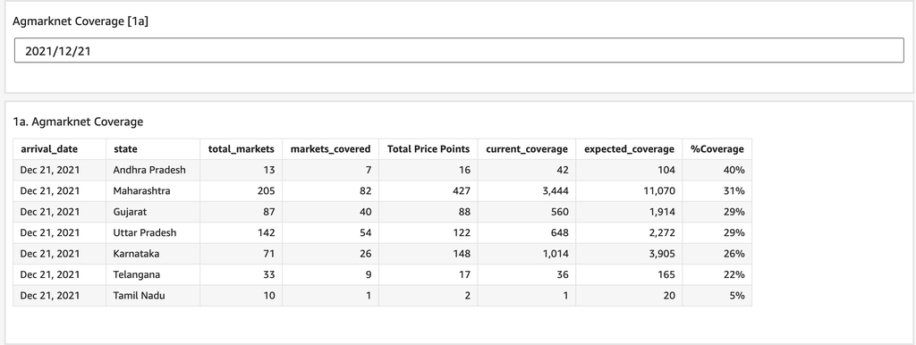

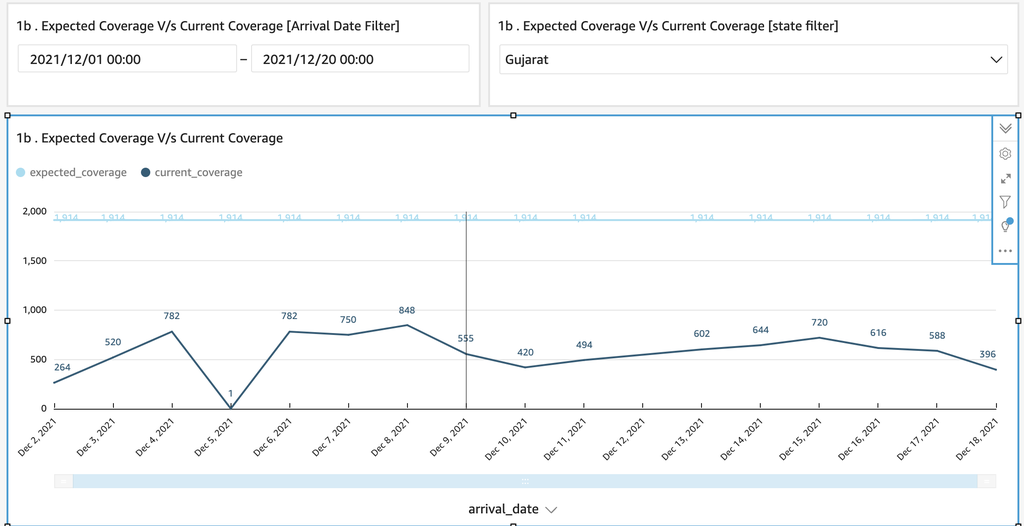

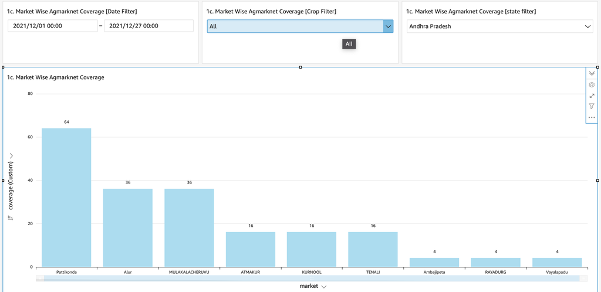

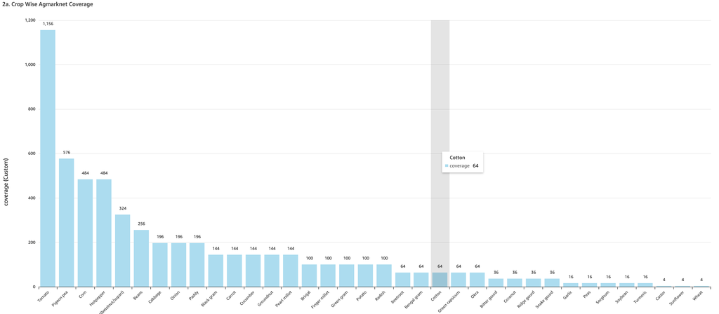

# Sheduling and running on daily basis on AWS Lambda Function and Getting Alerts into Microsoft teams

```python
import requests
import json
import pandas as pd
import urllib3
from sqlalchemy import create_engine
http=urllib3.PoolManager()
import psycopg2



agmarknet_insert = """
INSERT INTO agmarknet (state,district ,market , commodity ,variety, arrival_date  ,min_price    ,max_price  ,modal_price ) VALUES (%s, %s, %s, %s, %s, %s, %s,%s,%s) """

web_hk_url='https://bigdata348.webhook.office.com/webhookb2/67ed8852-6de4-4fa0-ac89-4c9c0bb3a4ce@3e8db0ca-95a6-4914-bac6-6cab03d9aa54/IncomingWebhook/fa2ad6575650437ba8929b982fde8eca/2c052b0c-c6da-4874-90a0-43ed59bdb83f'
def smsg(nor,db,table,movement_type):
    msg = {
        "@context": "https://schema.org/extensions",
        "@type": "MessageCard",
        "themeColor": "64a837",
        "title": "Agmarknet Data Append",
        "text":f"Data scuccesfully updated ",
        "sections":[
            {
                "facts": [
                    {
                        "name": "No of Records ",
                        "value": nor
                    },
                    {
                        "name": "Upload database",
                        "value": db
                    },
                    {
                        "name": "Upload table",
                        "value": table
                    },
                    {
                        "name":"Movement Type",
                        "value":movement_type
                    }



                ]
            }
        ]
    }
    encoded_msg = json.dumps(msg).encode('utf-8')
    resp = http.request('POST',web_hk_url, body=encoded_msg)


def lambda_handler(event,context):
    url = "https://api.data.gov.in/resource/9ef84268-d588-465a-a308-a864a43d0070?api-key=579b464db66ec23bdd000001d9143fc81ac74bce7ad727abc2705a8a&format=csv&limit=10000"

    payload={}
    headers = {
      'accept': 'application/xml',
      'Cookie': 'BIGipServerapi.data.gov.in=!3+MbghwZgEPYHt6CbbshOuMRiHS6yPaTO/SoI8x2yuzWQTb260vG8vD/gim86FybvljnTZREBSVVyQ==; TS01a12685=0161d6dfc399201b55df766bb2117226b37bf28203848e59b7a982f2aaaf1352b4e590defb37aa8dd56601356220b9bc91328274e7; TS01a12685028=01e4def216eb6f369607dd6aaa5eca2f193f115ae365c13592f7be6de97164e5ec81a274c42a7ed178cfaad301add56178616e7022'
    }

    response = requests.request("GET", url, headers=headers, data=payload)
    x=response.text
    listt=x.split("\n")

    columns=listt[0].split(",")

    State=[]
    District=[]
    Market=[]
    Commodity=[]
    Variety=[]
    Arrival_Date=[]
    Min_x0020_Price=[]
    Max_x0020_Price=[]
    Modal_x0020_Price=[]

    for i in listt[1:-1]:
        State.append(i.split(',')[0])
        District.append(i.split(',')[1])
        Market.append(i.split(',')[2])
        Commodity.append(i.split(',')[3])
        Variety.append(i.split(',')[-5])
        Arrival_Date.append(i.split(',')[-4])
        Min_x0020_Price.append(i.split(',')[-3])
        Max_x0020_Price.append(i.split(',')[-2])
        Modal_x0020_Price.append(i.split(',')[-1])

    df=pd.DataFrame({'State':State,'District':District,'Market':Market,"Commodity":Commodity,"Variety":Variety,"Arrival_Date":Arrival_Date,"Min_Price":Min_x0020_Price,"Max_Price":Max_x0020_Price,"Modal_Price":Modal_x0020_Price})

    conn = psycopg2.connect("host=127.0.0.1 dbname=postgres user=postgres password=postgres")
    cur = conn.cursor()
    for index, row in df.iterrows():
        cur.execute(agmarknet_insert, list(row.values))
        conn.commit()

    nor=len(df)
    db='postgres'
    table='agmarknet'
    movement_type='append'
    smsg(nor,db,table,movement_type)
```

```python
lambda_handler('a','b')
```